# ch10_sum

An **impacted tooth** is one that fails to fully erupt into the dental arch within the usual range of expected time. This occurs due to abnormal tooth orientation, adjacent teeth, dense overlying bone, excessive soft tissue, or genetic abnormality. **Unerupted teeth** includes impacted teeth and teeth that are in the process of developing and erupting. The most common impacted teeth are maxillary and mandibular third molars, followed by maxillary canines and mandibular premolars.

> As a general rule, all impacted teeth should be removed unless removal is contraindicated. Early removal reduces postoperative morbidity and allows for the best healing, particularly in younger patients who tolerate the procedure better, recover more quickly, and show better periodontal and nerve healing. The ideal time for removal of impacted third molars is when the roots are one-third formed and before they are two-thirds formed, typically between 16 and 20 years of age.

### **Indications for Removal of Impacted Teeth**

- **Normal Eruption:** Average age for third molar eruption is 20 years (may continue to 25). Failure of rotation from mesioangular to vertical, or inadequate arch length, are common causes of impaction.
- **Prediction of Impaction:** If a third molar has not erupted by age 20, it is likely covered with bone, often a mesioangular impaction, and positioned low in the alveolar process.

#### **Prevention of Periodontal Disease**

- Impacted third molars predispose adjacent second molars to periodontal disease, including bone loss and deep pockets on the distal aspect, which is exacerbated in maxillary molars due to early furcation involvement.
- Early removal prevents disease and promotes optimal bone fill.

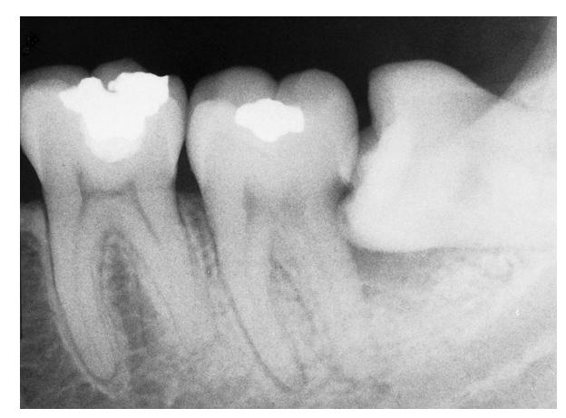

• Fig. 10.1 Radiograph of a mandibular third molar impacted against a second molar with bone loss resulting from the presence of a third molar.

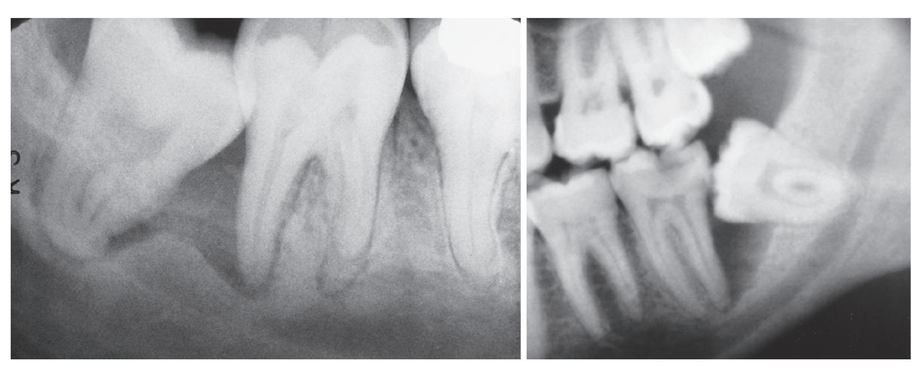

• Fig. 10.2 Radiographs showing variations of a mandibular third molar impacted against a second molar with severe bone loss resulting from periodontal disease and a third molar.

#### **Prevention of Dental Caries**

- Impacted or partially impacted third molars can lead to caries on their own crown or on the distal aspect of adjacent second molars due to bacterial exposure, even with subtle communication.

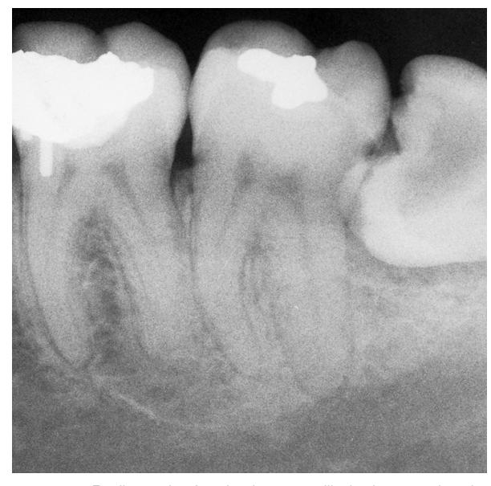

• Fig. 10.4 Radiograph of caries in a mandibular impacted molar.

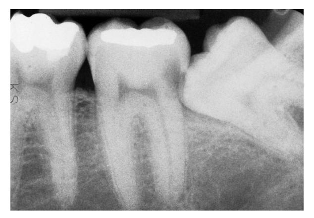

• Fig. 10.3 Radiograph of caries in a mandibular second molar resulting from the presence of an impacted third molar.

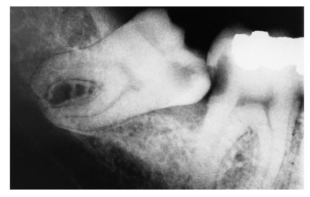

Fig. 10.5 Radiograph of caries in an impacted third molar and a second molar.

#### **Prevention of Pericoronitis**

- **Definition:** An infection of the soft tissue (operculum) around the crown of a partially impacted tooth, typically caused by normal oral flora.
- **Causes:** Compromised host defenses, trauma from an opposing maxillary third molar, or food entrapment under the operculum.
- **Treatment Protocols:**
  - **Mild (localized swelling, soreness):** Dentist performs irrigation and curettage; patient performs home irrigations (e.g., with hydrogen peroxide, chlorhexidine, iodophors, or saline).
  - **Slightly more severe (large local swelling, traumatized by opposing maxillary third molar):** Consider immediate extraction of the maxillary third molar, plus local irrigation.
  - **Moderately severe (local swelling/pain, mild facial swelling, mild trismus, low-grade fever):** Systemic antibiotic (penicillin, or clindamycin for allergy), pressure irrigation, and extraction.
  - **Severe (trismus >20 mm, temperature >101°F, facial swelling, pain, malaise):** Referral to an oral-maxillofacial surgeon for hospitalization, parenteral antibiotics, monitoring, and surgical extraction.
- **Recurrence:** Patients with one episode are highly likely to have recurrences unless the impacted tooth is removed. > The mandibular third molar should not be removed until the signs and symptoms of pericoronitis have completely resolved, as removal during active infection increases postoperative complications (dry socket, infection, bleeding, slower healing).
- **Prevention:** Achieved by removing impacted third molars before oral mucosa penetration. > Operculectomy (excision of surrounding soft tissue) is generally painful and ineffective, as tissue tends to recur and the gingival pocket remains deep.

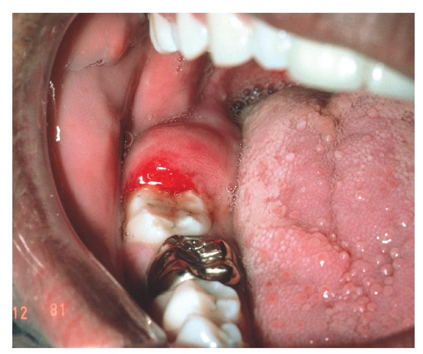

• Fig. 10.6 Pericoronitis in the area of impacted tooth #32 exhibiting classic signs of inflammation with erythema and swelling. If opposing tooth #1 is erupted, it commonly impinges on this area of swelling when teeth are brought into occlusion, causing even more pain and swelling.

#### **Prevention of Root Resorption**

- Impacted teeth can exert pressure on adjacent tooth roots, leading to external root resorption.
- Removal of the impacted tooth may allow for salvage of the adjacent tooth through cemental repair; endodontic therapy may be required.

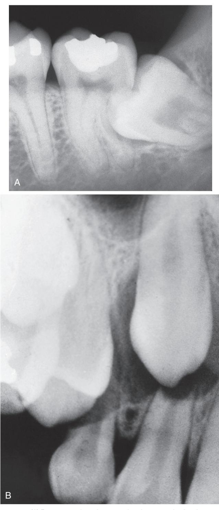

• Fig. 10.7 (A) Root resorption of a second molar as result of an impacted third molar. (B) Root resorption of maxillary lateral incisors as a result of an impacted canine.

#### **Impacted Teeth Under a Dental Prosthesis**

- Removal before prosthesis construction is indicated to prevent future complications:
  - Alveolar resorption can expose the impacted tooth, leading to ulceration and infection under tissue-borne prostheses.
  - Post-prosthesis removal alters the ridge, affecting prosthesis function.
  - Avoids extraction in older, potentially medically compromised patients with atrophic mandibles (increased fracture risk).
  - Eliminates risk of interference with planned dental implants.

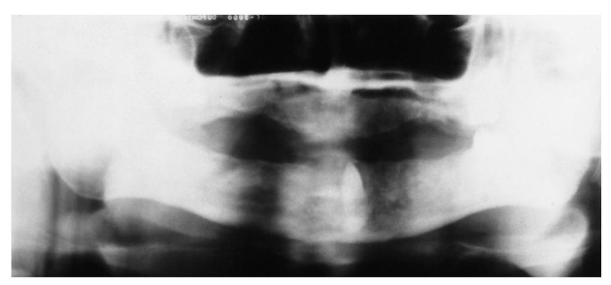

• Fig. 10.8 Impacted canine retained under a denture. The tooth is now at the surface and is causing infection.

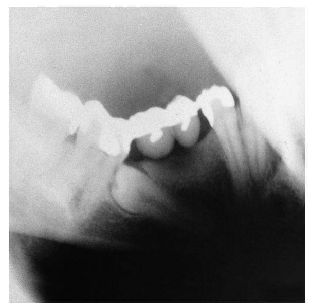

• Fig. 10.9 Impacted tooth under a fixed bridge. The tooth must be removed and therefore may jeopardize the bridge.

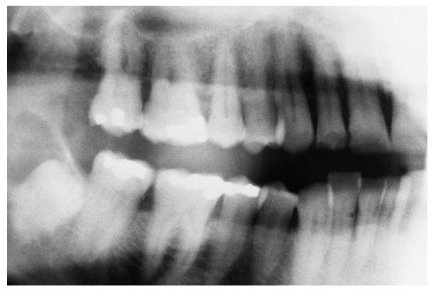

• Fig. 10.11 Small dentigerous cyst arising around an impacted tooth.

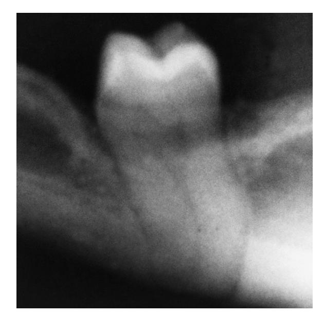

• Fig. 10.10 Impaction in an atrophic mandible, which may result in jaw fracture during extraction.

#### **Prevention of Odontogenic Cysts and Tumors**

- The follicular sac around completely impacted teeth can undergo cystic degeneration.
- **Dentigerous cyst:** A preoperative diagnosis is reasonable if the follicular space around the crown is greater than 3 mm. These cysts can become very large.
- **Odontogenic tumors:** Epithelium within the dental follicle can give rise to tumors like ameloblastoma (often requires aggressive excision) or other odontogenic tumors.
- The majority of pathologic conditions of the mandibular third molar are associated with unerupted teeth.

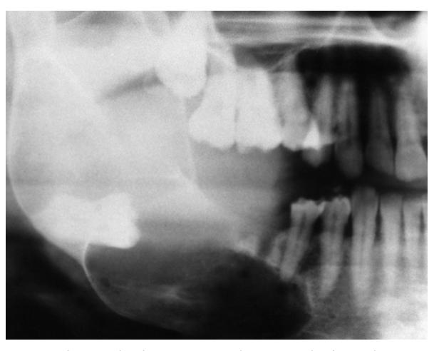

• Fig. 10.12 Large dentigerous cyst that extends from the coronoid process to the mental foramen. The cyst has displaced the impacted third molar to the inferior border of the mandible.

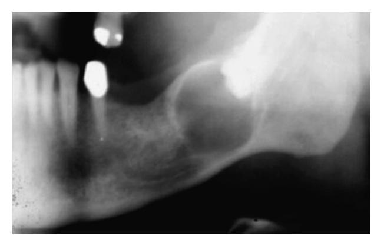

• Fig. 10.13 Ameloblastoma associated with the crown of an impacted third molar. (Courtesy Dr. Frances Gordy.)

#### **Treatment of Pain of Unexplained Origin**

- If myofascial pain dysfunction syndrome and other facial pain disorders are excluded, removal of an unerupted tooth may resolve unexplained retromolar pain.
- Delaying third molar removal may increase the risk of temporomandibular disorders.

#### **Prevention of Jaw Fractures**

- An impacted mandibular third molar weakens the jaw, making it more susceptible to fracture.
- If a fracture occurs through the impaction site, the tooth is often removed before fracture reduction and fixation.

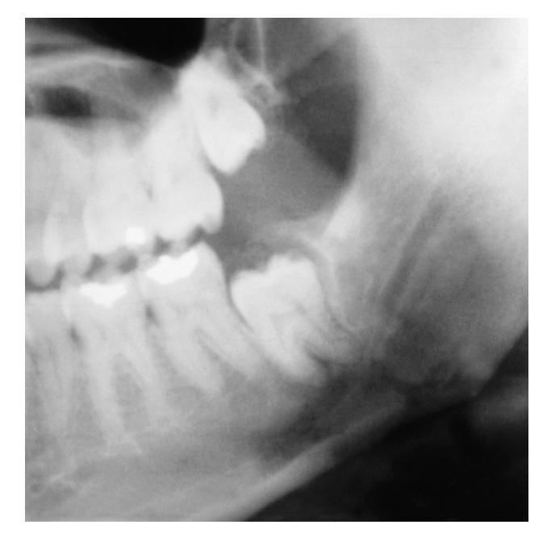

• Fig. 10.14 Fracture of a mandible, which occurred through the location of an impacted third molar.

#### **Facilitation of Orthodontic Treatment**

- Impacted third molars can interfere with orthodontic retraction of first and second molars; removal is recommended pre-treatment.
- Necessary for placement of retromolar implants for distal anchorage.

#### **Optimal Periodontal Healing**

- Essential for preserving the periodontal health of the adjacent second molar.
- **Primary Parameters:** Bone height and periodontal attachment level on the distal aspect of the second molar.
- **Most Important Factors:**
  1. Extent of the preoperative infrabony defect on the distal aspect of the second molar.
  2. Patient’s age at the time of surgery (patients <25 years have better initial and long-term periodontal regeneration).
- Late eruption increases the risk of pericoronitis and contact with the second molar, both reducing optimal periodontal healing. > Asymptomatic completely bony impacted third molars in patients older than 30 years should probably be left in place unless specific pathologic conditions develop, as removal in older patients can result in greater pocket depths and alveolar bone loss than if the tooth were left in place.

### **Contraindications for Removal of Impacted Teeth**

Removal is contraindicated when potential risks outweigh potential benefits. This primarily involves the patient’s physical status.

#### **Extremes of Age**

- **Very Early Age (7-9 years):** Most surgeons defer removal of tooth buds until an accurate diagnosis of impaction can be made.
- **Advanced Age (>35 years):** The most common contraindication.
  - Bone becomes highly calcified, less flexible, and requires more surgical removal.
  - Older patients experience less favorable response and more postoperative sequelae (e.g., longer recovery). > If an impacted tooth has been retained for many years without periodontal disease, caries, or cystic degeneration in an older patient (usually >35 years) with a radiographically detectable layer of overlying bone, it should not be removed. Radiographic monitoring every 1-2 years is recommended.
  - Removal is still indicated if the tooth shows signs of cystic formation, periodontal disease, is a single impacted tooth under a prosthesis with thin overlying bone, or becomes symptomatic due to infection.

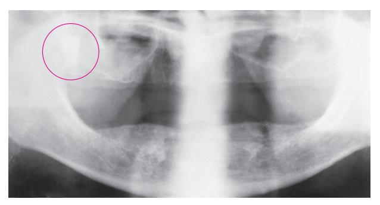

• Fig. 10.15 Impacted maxillary right third molar in a 63-year-old patient. This molar should not be extracted because it is deeply embedded and no signs of disease are present.

#### **Compromised Medical Status**

- Removal of an asymptomatic impacted tooth is elective.
- If a patient has serious cardiovascular or respiratory compromise, impaired host defenses, or a severe coagulopathy, leaving the tooth in place should be considered.
- If the tooth becomes symptomatic, the surgeon should collaborate with the patient’s physician for removal with minimal sequelae.

#### **Probable Excessive Damage to Adjacent Structures**

- If removal risks serious damage to adjacent nerves, teeth, or pre-existing bridges, it may be prudent to leave the tooth.
- This decision weighs potential damage against future complications. In younger patients with higher risk of sequelae, removal with special precautions might be warranted. In older patients with low probability of complications, the tooth should not be removed (e.g., risk of losing an adjacent second molar due to severe periodontal defect).

### **Treatment Planning**

Decision-making involves weighing various factors regarding risks and benefits.

- **Pathologic Symptoms/Problems:** Impacted teeth causing symptoms or problems should be removed (more common with partially erupted teeth).
- **Asymptomatic Teeth:**
  - Consider available room in the arch for eruption.
  - Consider tooth status and patient age (eruption may continue to 25 years).
  - If an adjacent second molar is diseased and likely to be removed, leaving the third molar might allow it to erupt into occlusion.
  - Insufficient room coupled with a soft tissue operculum makes pathologic sequelae likely. > By the time a patient reaches 18 years, the dentist can reasonably predict if there will be adequate room for functional eruption. If not, removal of the asymptomatic third molar at this age optimizes soft tissue and bone healing, and long-term periodontal health of the second molar.

### **Classification Systems for Assessing Surgical Difficulty**

The purpose of classification is to determine preoperative difficulty and predict surgical approaches. The primary factor is accessibility, determined by adjacent structures, delivery pathway, ease of exposure, and purchase point preparation. A panoramic radiograph is the imaging of choice, though CBCT is useful for assessing roots near the inferior alveolar canal. Dentists should refer to a specialist if the situation is difficult or optimal pain/anxiety control cannot be provided.

#### **Classification of Mandibular Third Molar Impactions**

##### **Angulation**

This classifies the long axis of the impacted third molar relative to the second molar.

- **Mesioangular Impaction (approx. 43%):** Least difficult to remove, especially if partially impacted.
- **Horizontal Impaction (approx. 3%):** More difficult than mesioangular.
- **Vertical Impaction (approx. 38%):** Third in ease of removal.
- **Distoangular Impaction (approx. 6%):** Most difficult to remove; withdrawal pathway runs into mandibular ramus, requiring significant intervention.
- **Other:** Buccal, lingual, or rare transverse impactions (buccolingual horizontal). Lingual inclination does not preclude a buccal approach due to lingual nerve risk.

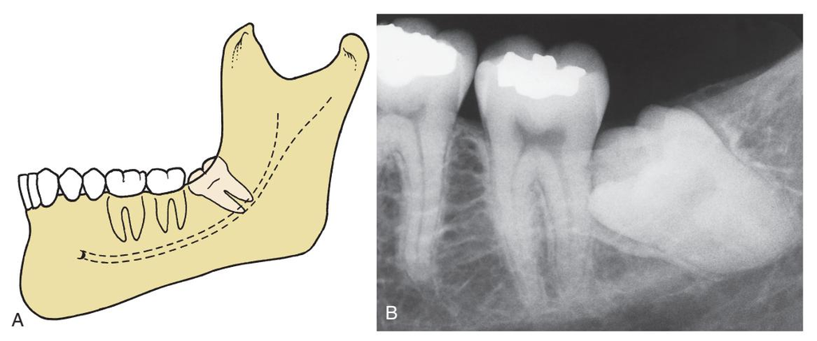

Fig. 10.16 (A) Mesioangular impaction—the most common and easiest impaction to remove. (B) Mesio-angular impaction is usually in proximity to the second molar.

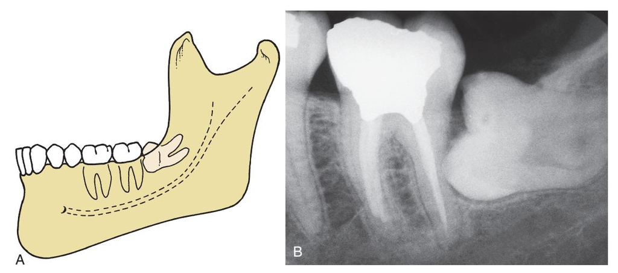

• Fig. 10.17 (A) Horizontal impaction—an uncommon and more difficult to remove impaction than a mesioangular impaction. (B) The occlusal surface of the horizontal impacted third molar is usually immediately adjacent to the root of the second molar, which often produces early severe periodontal disease.

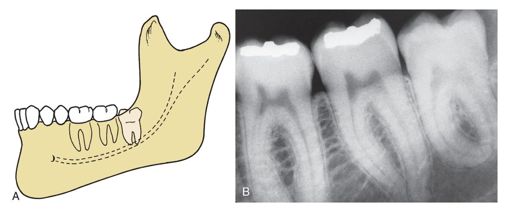

Fig. 10.18 (A) Vertical impaction—the second most common impaction and the second most difficult to remove. (B) Vertical impaction is frequently covered on its posterior aspect with bone of the anterior ramus of the mandible.

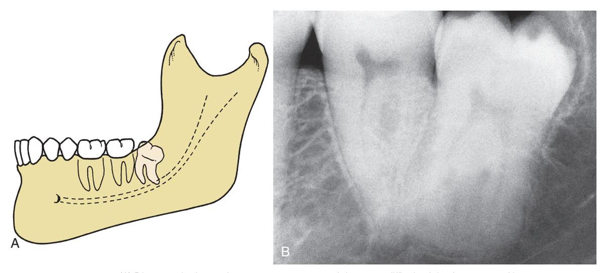

• Fig. 10.19 (A) Distoangular impaction — an uncommon and the most difficult of the four types of impac-tions to remove. (B) The occlusal surface of distoangular impaction is usually embedded in the ramus of the mandible and requires significant bone removal for extraction.

##### **Relationship to Anterior Border of Ramus**

The **Pell and Gregory Classification (Classes 1, 2, 3)** is based on the amount of impacted tooth covered by the mandibular ascending ramus bone.

- **Class 1:** Mesiodistal diameter of the crown is completely anterior to the anterior border of the ramus. Greatest accessibility, most straightforward.
- **Class 2:** Approximately one-half of the tooth is covered by the ramus.
- **Class 3:** Tooth is located completely within the mandibular ramus. Least accessibility, greatest difficulty.

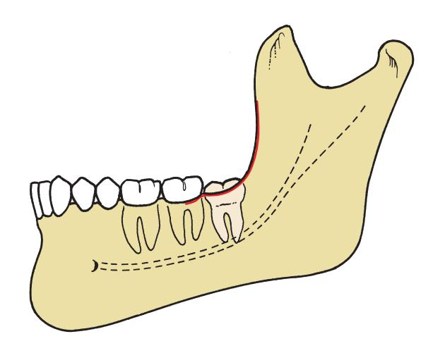

• Fig. 10.20 Pell and Gregory class 1 impaction. The mandibular third molar has sufficient anteroposterior room (i.e., anterior-to-anterior border of ramus) to erupt.

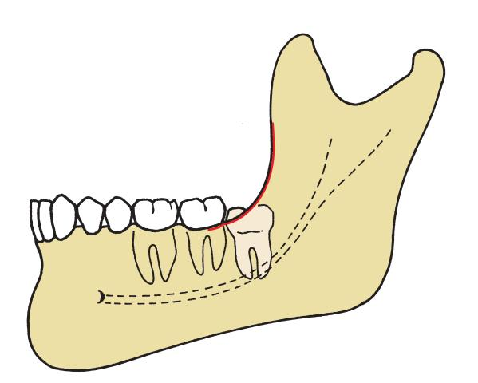

• Fig. 10.21 Pell and Gregory class 2 impaction. Approximately half is covered by the anterior portion of the ramus of the mandible.

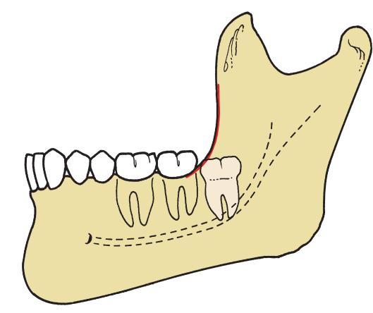

• Fig. 10.22 Pell and Gregory class 3 impaction. The impacted third molar is completely embedded in the bone of the ramus of the mandible.

##### **Relationship to the Occlusal Plane**

The **Pell and Gregory A, B, C Classification** measures the depth of the impacted tooth relative to the adjacent second molar’s occlusal plane. Difficulty increases with depth (thickness of overlying bone).

- **Class A:** Occlusal surface is level or nearly level with the occlusal plane of the second molar.
- **Class B:** Occlusal surface is between the occlusal plane and the cervical line of the second molar.
- **Class C:** Occlusal surface is below the cervical line of the second molar.

**Combined Classification:** These three systems (angulation, ramus, occlusal plane) are used together to assess overall difficulty (e.g., Mesioangular, Class 1, Class A is easiest; Distoangular, Class 3, Class C is most difficult).

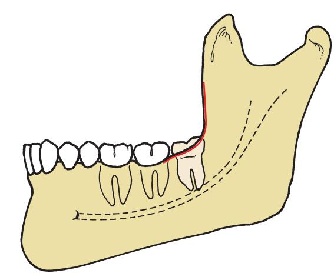

• Fig. 10.23 Pell and Gregory class A impaction. The occlusal plane of the impacted tooth is at the same level as the occlusal plane of the second molar.

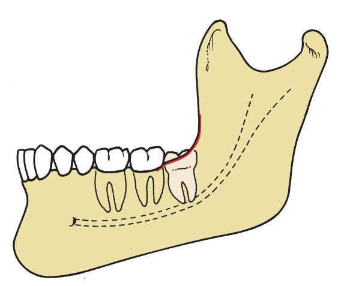

• Fig. 10.24 Pell and Gregory class B impaction. The occlusal plane of the impacted tooth is between the occlusal plane and the cervical line of the second molar.

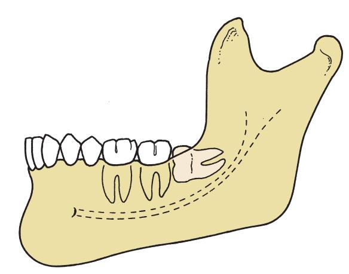

• Fig. 10.27 Horizontal impaction with class 2 ramus relationship and class B depth makes it moderately difficult to extract.

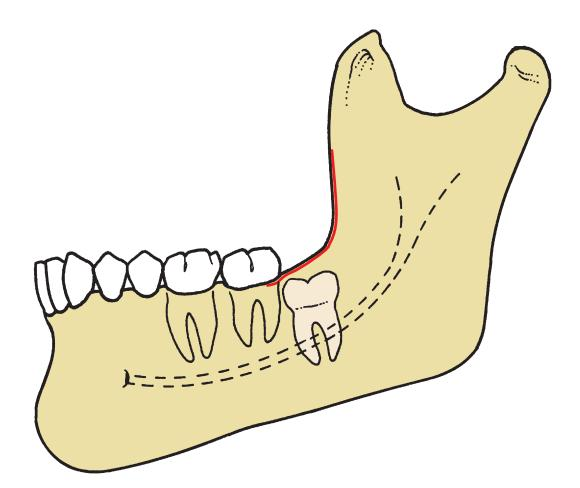

• Fig. 10.25 Pell and Gregory class C impaction. The impacted tooth is below the cervical line of the second molar.

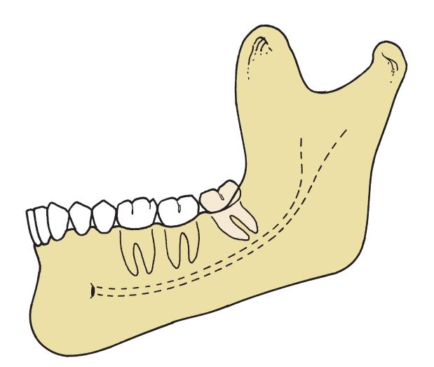

• Fig. 10.26 Mesioangular impaction with class 1 ramus relationship and class A depth. All three classifications make this the easiest type of impaction to remove.

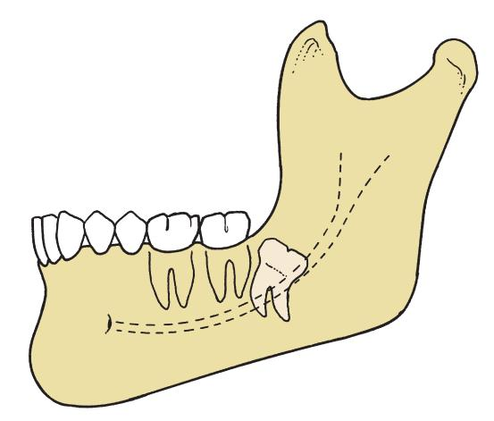

• Fig. 10.28 Impaction with a distoangular class 3 ramus relationship and class C depth makes the tooth extremely difficult to remove safely.